# Análisis de Datos I Tarea 7

# Librerías

```r
library(cluster)
library(dplyr)
library(factoextra)
```

# Ejercicio 2

**La tabla de datos VotosCongresoUS.csv la cual contiene 16 votos (y=Sí, n=No, NS=No votó) dados por los congresistas de Estados Unidos respecto a 16 temáticas diferentes, además en la primera columna aparece el partido al que pertenecen (Republicano o Demócrata).**

## a) Ejecute una clasificación jerárquica sobre esta tabla de datos usando la función daisy ya que los datos son cualitativos. Use métrica euclidean y método complete (deje el resultado en la variable jer).

```r
Datos <- read.csv("VotosCongresoUS.csv",header=TRUE, sep=",", dec=".")
Datos[] <- lapply(Datos, function(x) if(is.character(x)) as.factor(x) else x)
D <- daisy(Datos, metric = "euclidean")
jer <- hclust(D, method = "complete")
```

## b) Luego “corte” el árbol usando 3 clústeres y ejecute el siguiente código y explique qué hace el código.

La función cutree() corta el árbol generado por la función hclust() en varios grupos. Los parámetros que recibe la función son el árbol, k que es el número de grupos que se desean y h la altura del corte. Crea un vector con el número de grupo para cada individuo.

```r
grupo <- cutree(jer, k = 3)
```

Se combinan el dataframe Datos y el vector generado grupo por columnas por medio de la función cbind.

```r
NDatos <- cbind(Datos,grupo)
```

Se asigna a la variable cluster la columna grupo del dataframe Ndatos.

```r
cluster <- NDatos$grupo
```

La función match() devuelve un vector de las posiciones de las primeras coincidencias de su primer argumento en su segundo argumento. El tercer argumento se refiere al valor que se devolverá en caso de que no se encuentre ninguna coincidencia y debe ser de tipo int. Para este caso el primer argumento es la variable cluster y lo compara con un vector de unos y al no coincidir le asigna un cero.

```r
sel.cluster1 <- match(cluster,c(1),0)
```

Se le asigna a la variable Datos.Cluster1 el dataframe con todas las filas de NDatos donde sel.cluster1 es mayor que 0. En otras palabaras, va a seleccionar los individuos que pertenecen al cluster 1.

```r
Datos.Cluster1 <- NDatos[sel.cluster1>0,]
```

Retorna las dimensiones de Datos.Cluster1.

```r
dim(Datos.Cluster1)
```

```
## [1] 232  18
```

Ahora se compara la variable cluster con un vector de 2.

```r
sel.cluster2 <- match(cluster,c(2),0)
```

Se seleccionan los individuos que pertenecen al cluster 2.

```r
Datos.Cluster2 <- NDatos[sel.cluster2>0,]
```

Se retorna las dimensiones del dataframe Datos.Cluster2.

```r
dim(Datos.Cluster2)
```

```
## [1] 198  18
```

Se compara la variable cluster con un vector de 3.

```r
sel.cluster3 <- match(cluster,c(3),0)
```

Se seleccionan los individuos que pertenecen al cluster 3.

```r
Datos.Cluster3 <- NDatos[sel.cluster3>0,]
```

Se retorna las dimensiones del dataframe Datos.Cluster3.

```r
dim(Datos.Cluster3)
```

```
## [1]  5 18
```

**Luego ejecute el siguiente código:**

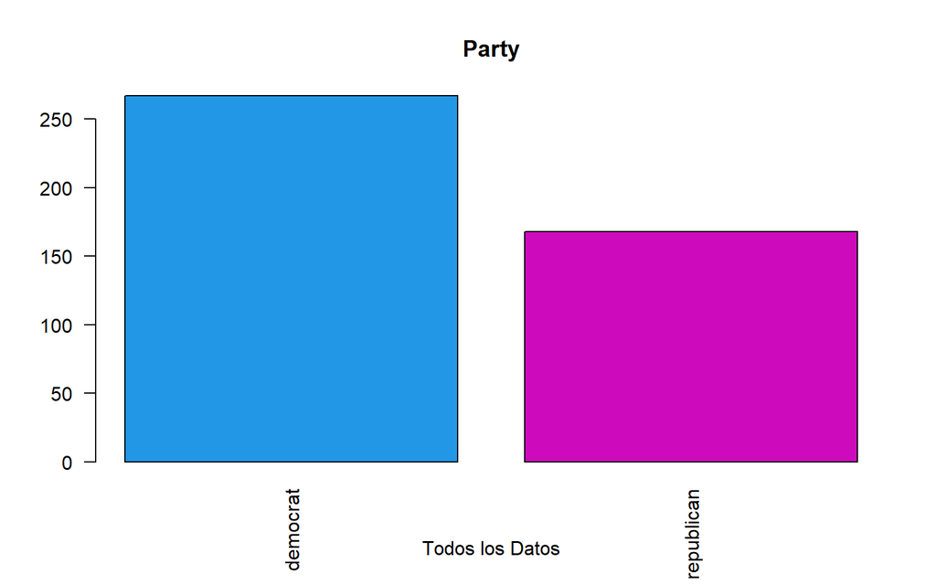

```r
plot(Datos$Party,col=c(4,6),las=2,main="Party",xlab="Todos los Datos")
```

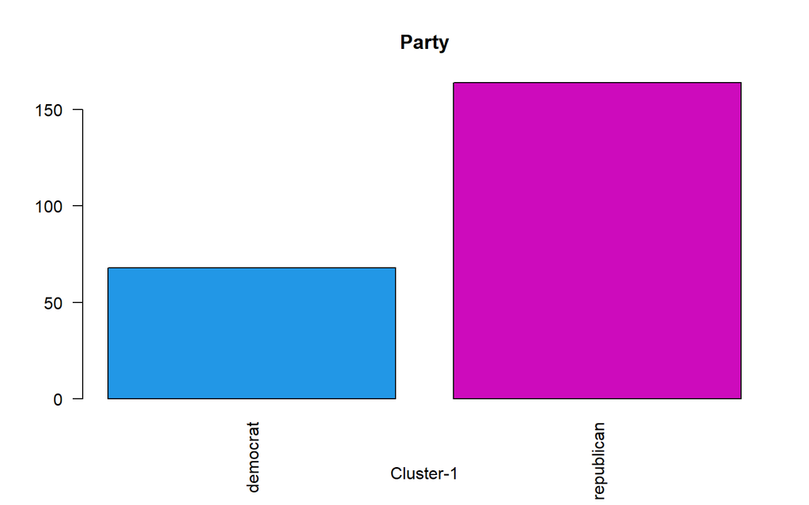

```r
plot(Datos.Cluster1$Party,col=c(4,6),las=2,main="Party",xlab="Cluster-1")
```

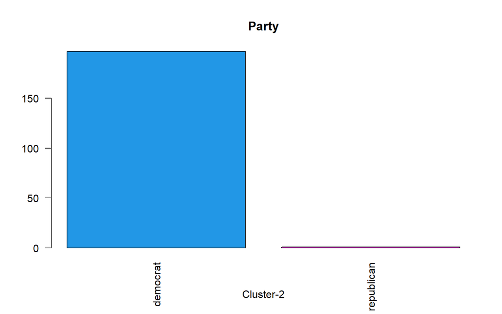

```r
plot(Datos.Cluster2$Party,col=c(4,6),las=2,main="Party",xlab="Cluster-2")
```

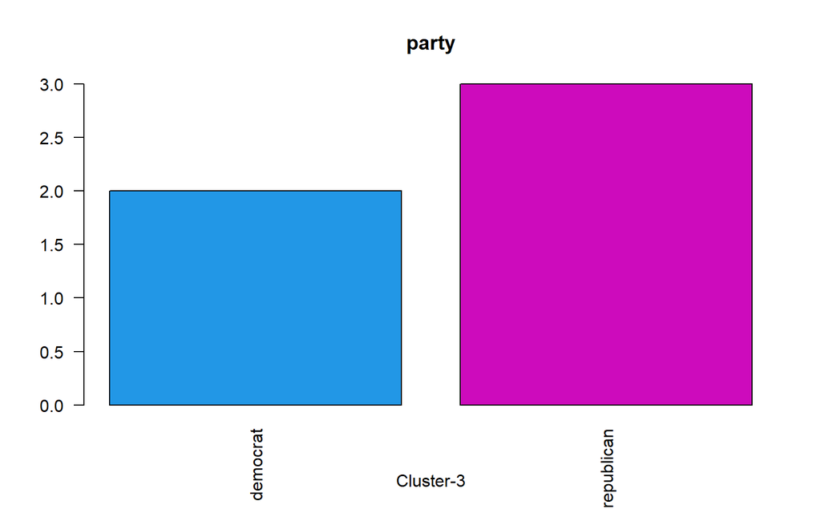

```r
plot(Datos.Cluster3$Party,col=c(4,6),las=2,main="party",xlab="Cluster-3")
```

# Ejercicio 3

**Realice un análisis similar al del ejercicio anterior con la tabla de datos CompraBicicletas.csv.**

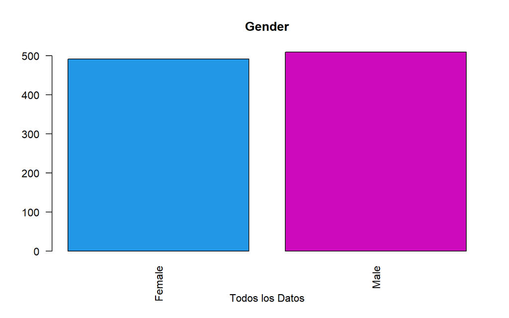

```r
Datos <- read.csv("CompraBicicletas.csv",header=TRUE, sep=";")
Datos[] <- lapply(Datos, function(x) if(is.character(x)) as.factor(x) else x)
D <- daisy(Datos, metric = "euclidean")
jer <- hclust(D, method = "complete")
grupo <- cutree(jer, k = 3)
NDatos <- cbind(Datos,grupo)
cluster <- NDatos$grupo
sel.cluster1 <- match(cluster,c(1),0)
Datos.Cluster1 <- NDatos[sel.cluster1>0,]
sel.cluster2 <- match(cluster,c(2),0)
Datos.Cluster2 <- NDatos[sel.cluster2>0,]
sel.cluster3 <- match(cluster,c(3),0)
Datos.Cluster3 <- NDatos[sel.cluster3>0,]


plot(Datos$Gender,col=c(4,6),las=2,main="Gender",xlab="Todos los Datos")
```

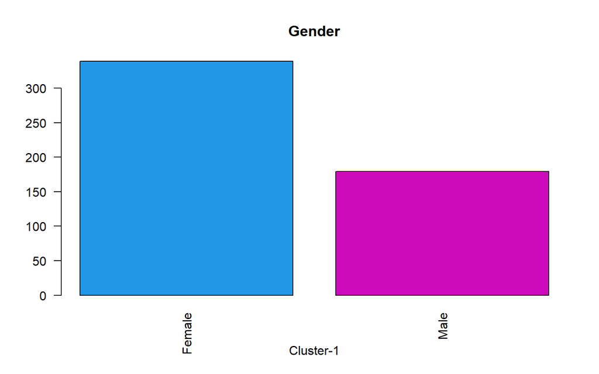

```r
plot(Datos.Cluster1$Gender,col=c(4,6),las=2,main="Gender",xlab="Cluster-1")
```

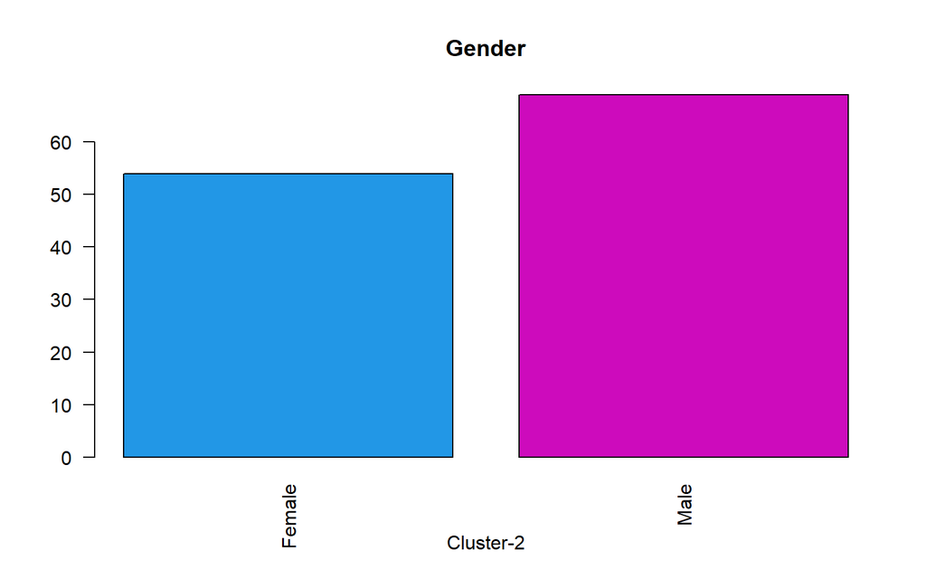

```r
plot(Datos.Cluster2$Gender,col=c(4,6),las=2,main="Gender",xlab="Cluster-2")
```

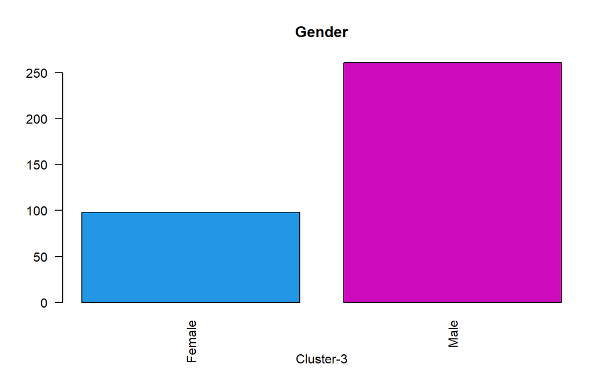

```r
plot(Datos.Cluster3$Gender,col=c(4,6),las=2,main="Gender",xlab="Cluster-3")
```

Si se realiza un análisis con respecto al género de la persona, se cumple que en general la base de datos cuenta con 1000 individuos divididos con la misma cantidad de hombres y mujeres. Sin embargo, al analizar por cluster se tiene que el cluster 1 se encuentra formado por 518 individuos de ellos más de 300 son mujeres y un poco menos de 200 son hombres. El cluster 2 posee 123 observaciones y para este caso, contraio al anterior, se tienen más hombres que mujeres, aproximadamente 70 y 50 respectivamente. En el último cluster se tiene el mismo comportamiento que el 2, pero con una cantidad de 100 individuos de género femenino y más de 259 de género masculino, para un total de 359 individuos en el presente cluster.

# Ejercicio 6

## a) Demuestre que la distancia de Chebychev efectivamente es una distancia.

[figure not shown]

## b) Programe una función en R que calcula la distancia de Chebychev entre dos vectores.

```r
Chebychev <- function(vector1, vector2){
  restas <- numeric(length(vector1)-1)
  for (i in 1:length(vector1)) {
    restas[i] <- abs(vector1[i] - vector2[i])
  }
  restas <- unlist(restas)
  distancia <- max(restas)
  return(distancia)
}
```

## c) Programe una función en R que recibe un DataFrame calcula la matriz de distancias usando la distancia de Chebychev entre dos vectores calculada anteriormente.

```r
matriz_distancias <- function(dataframe){
  n <- nrow(dataframe)
  p <- ncol(dataframe)
  matriz <- matrix(NA, nrow = n, ncol = n)

  for (i in 1:n) {
    for (j in 1:n) {
      matriz[i,j] <- Chebychev(dataframe[i,2:p], dataframe[j,2:p])
    }
  }

  rownames(matriz) <- dataframe[,1]
  colnames(matriz) <- dataframe[,1]
  return(matriz)
}
```

## d) Para la tabla de datos EjemploAlgoritmosRecomendacion.csv ejecute un Clustering Jerárquico de Chebychev y la agregación Ward. Compare el resultado con el obtenido en el ejercicio 1 usando distancia euclidea.

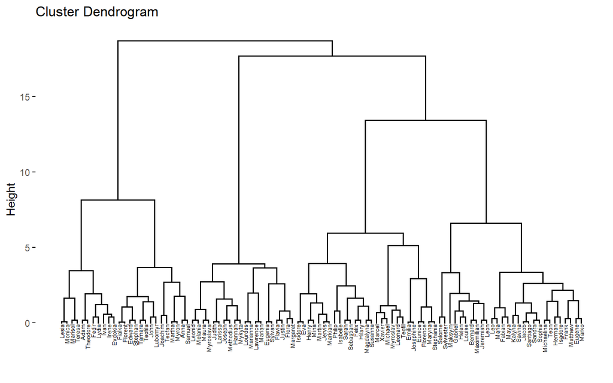

```r
Datos6 <- read.csv("EjemploAlgoritmosRecomendacion.csv",header=TRUE, sep=";",
                   dec=",")

distancias <- matriz_distancias(Datos6)
distancias <- as.dist(distancias)
clustering <- hclust(distancias, method = "ward.D")
fviz_dend(clustering, cex = 0.4, repel = TRUE)
```